# Qualitative Assessment of Weight Lifting Exercises

kurunaadan

Sunday, August 23, 2015

## Overview

Physical activity leads to a healthy life. It can reduce potential attacks of diseases like heart attack, type 2 diabetes and so on. Training in an effective way is important factor for a positive impact whereas mistakes during exercises would harm the individual. *Free weights* accounts for most of weight related training exercises. There are two ways to monitior the exercise regimen. One is employing a personal coach and the other is using on-body sensors and analyze the data obtained. It is possible to automatically assess the quality of execution of weight lifting exercises. In this project, we consider the data used by the following paper to find the most influential predictors.

*Velloso, E.; Bulling, A.; Gellersen, H.; Ugulino, W.; Fuks, H.* **Qualitative Activity Recognition of Weight Lifting Exercises.** Proceedings of 4th International Conference in Cooperation with SIGCHI (Augmented Human ’13) Stuttgart, Germany: ACM SIGCHI, 2013.

The data has 19622 observations taken from six individuals aged between 20-28 years, with little weight lifting experience. They were asked to perform one set of 10 repetitions of the Unilateral Dumbbell Biceps Curl in five different fashions: 1) exactly according to the specification (Class A), 2) throwing the elbows to the front (Class B), 3) lifting the dumbbell only halfway (Class C), 4) lowering the dumbbell only halfway (Class D) and 5) throwing the hips to the front (Class E).

Class A corresponds to the specified execution of the exercise, while the other 4 classes correspond to common mistakes. We use machine learning and pattern recognition techniques to detect mistakes and provide feedback on the quality of execution to the user.

## Exploratory Analysis

The following table shows the first three observations with every attribute.

Table continues below

| X | user_name | raw_timestamp_part_1 | raw_timestamp_part_2 |
| --- | --- | --- | --- |
| 1 | carlitos | 1.323e+09 | 788290 |
| 2 | carlitos | 1.323e+09 | 808298 |
| 3 | carlitos | 1.323e+09 | 820366 |

Table continues below

| cvtd_timestamp | new_window | num_window | roll_belt |
| --- | --- | --- | --- |
| 05/12/2011 11:23 | no | 11 | 1.41 |
| 05/12/2011 11:23 | no | 11 | 1.41 |
| 05/12/2011 11:23 | no | 11 | 1.42 |

Table continues below

| pitch_belt | yaw_belt | total_accel_belt | kurtosis_roll_belt |
| --- | --- | --- | --- |
| 8.07 | -94.4 | 3 |  |
| 8.07 | -94.4 | 3 |  |
| 8.07 | -94.4 | 3 |  |

[output not shown]

Table continues below

| skewness_roll_belt.1 | skewness_yaw_belt | max_roll_belt |
| --- | --- | --- |
|  |  | NA |
|  |  | NA |
|  |  | NA |

Table continues below

| max_picth_belt | max_yaw_belt | min_roll_belt | min_pitch_belt |
| --- | --- | --- | --- |
| NA |  | NA | NA |
| NA |  | NA | NA |
| NA |  | NA | NA |

Table continues below

| min_yaw_belt | amplitude_roll_belt | amplitude_pitch_belt |
| --- | --- | --- |
|  | NA | NA |
|  | NA | NA |
|  | NA | NA |

Table continues below

| amplitude_yaw_belt | var_total_accel_belt | avg_roll_belt |
| --- | --- | --- |
|  | NA | NA |
|  | NA | NA |
|  | NA | NA |

Table continues below

| stddev_roll_belt | var_roll_belt | avg_pitch_belt |
| --- | --- | --- |
| NA | NA | NA |
| NA | NA | NA |
| NA | NA | NA |

Table continues below

| stddev_pitch_belt | var_pitch_belt | avg_yaw_belt |
| --- | --- | --- |
| NA | NA | NA |
| NA | NA | NA |
| NA | NA | NA |

Table continues below

| stddev_yaw_belt | var_yaw_belt | gyros_belt_x | gyros_belt_y |
| --- | --- | --- | --- |
| NA | NA | 0 | 0 |
| NA | NA | 0.02 | 0 |
| NA | NA | 0 | 0 |

Table continues below

| gyros_belt_z | accel_belt_x | accel_belt_y | accel_belt_z |
| --- | --- | --- | --- |
| -0.02 | -21 | 4 | 22 |
| -0.02 | -22 | 4 | 22 |
| -0.02 | -20 | 5 | 23 |

Table continues below

| magnet_belt_x | magnet_belt_y | magnet_belt_z | roll_arm |
| --- | --- | --- | --- |
| -3 | 599 | -313 | -128 |
| -7 | 608 | -311 | -128 |
| -2 | 600 | -305 | -128 |

Table continues below

| pitch_arm | yaw_arm | total_accel_arm | var_accel_arm |
| --- | --- | --- | --- |
| 22.5 | -161 | 34 | NA |
| 22.5 | -161 | 34 | NA |
| 22.5 | -161 | 34 | NA |

Table continues below

| avg_roll_arm | stddev_roll_arm | var_roll_arm | avg_pitch_arm |
| --- | --- | --- | --- |
| NA | NA | NA | NA |
| NA | NA | NA | NA |
| NA | NA | NA | NA |

Table continues below

| stddev_pitch_arm | var_pitch_arm | avg_yaw_arm | stddev_yaw_arm |
| --- | --- | --- | --- |
| NA | NA | NA | NA |
| NA | NA | NA | NA |
| NA | NA | NA | NA |

Table continues below

| var_yaw_arm | gyros_arm_x | gyros_arm_y | gyros_arm_z |
| --- | --- | --- | --- |
| NA | 0 | 0 | -0.02 |
| NA | 0.02 | -0.02 | -0.02 |
| NA | 0.02 | -0.02 | -0.02 |

Table continues below

| accel_arm_x | accel_arm_y | accel_arm_z | magnet_arm_x |
| --- | --- | --- | --- |
| -288 | 109 | -123 | -368 |
| -290 | 110 | -125 | -369 |
| -289 | 110 | -126 | -368 |

Table continues below

| magnet_arm_y | magnet_arm_z | kurtosis_roll_arm |
| --- | --- | --- |
| 337 | 516 |  |
| 337 | 513 |  |
| 344 | 513 |  |

Table continues below

[output not shown]

Table continues below

| skewness_pitch_arm | skewness_yaw_arm | max_roll_arm |
| --- | --- | --- |
|  |  | NA |
|  |  | NA |
|  |  | NA |

Table continues below

| max_picth_arm | max_yaw_arm | min_roll_arm | min_pitch_arm |
| --- | --- | --- | --- |
| NA | NA | NA | NA |
| NA | NA | NA | NA |
| NA | NA | NA | NA |

Table continues below

| min_yaw_arm | amplitude_roll_arm | amplitude_pitch_arm |
| --- | --- | --- |
| NA | NA | NA |
| NA | NA | NA |
| NA | NA | NA |

Table continues below

| amplitude_yaw_arm | roll_dumbbell | pitch_dumbbell | yaw_dumbbell |
| --- | --- | --- | --- |
| NA | 13.05217456 | -70.49400371 | -84.87393888 |
| NA | 13.13073959 | -70.63750507 | -84.71064711 |
| NA | 12.85074981 | -70.27811982 | -85.14078134 |

Table continues below

[output not shown]

Table continues below

[output not shown]

Table continues below

| skewness_pitch_dumbbell | skewness_yaw_dumbbell | max_roll_dumbbell |
| --- | --- | --- |
|  |  | NA |
|  |  | NA |
|  |  | NA |

Table continues below

| max_picth_dumbbell | max_yaw_dumbbell | min_roll_dumbbell |
| --- | --- | --- |
| NA |  | NA |
| NA |  | NA |
| NA |  | NA |

Table continues below

| min_pitch_dumbbell | min_yaw_dumbbell | amplitude_roll_dumbbell |
| --- | --- | --- |
| NA |  | NA |
| NA |  | NA |
| NA |  | NA |

Table continues below

| amplitude_pitch_dumbbell | amplitude_yaw_dumbbell |
| --- | --- |
| NA |  |
| NA |  |
| NA |  |

Table continues below

| total_accel_dumbbell | var_accel_dumbbell | avg_roll_dumbbell |
| --- | --- | --- |
| 37 | NA | NA |
| 37 | NA | NA |
| 37 | NA | NA |

Table continues below

| stddev_roll_dumbbell | var_roll_dumbbell | avg_pitch_dumbbell |
| --- | --- | --- |
| NA | NA | NA |
| NA | NA | NA |
| NA | NA | NA |

Table continues below

| stddev_pitch_dumbbell | var_pitch_dumbbell | avg_yaw_dumbbell |
| --- | --- | --- |
| NA | NA | NA |
| NA | NA | NA |
| NA | NA | NA |

Table continues below

| stddev_yaw_dumbbell | var_yaw_dumbbell | gyros_dumbbell_x |
| --- | --- | --- |
| NA | NA | 0 |
| NA | NA | 0 |
| NA | NA | 0 |

Table continues below

| gyros_dumbbell_y | gyros_dumbbell_z | accel_dumbbell_x |
| --- | --- | --- |
| -0.02 | 0 | -234 |
| -0.02 | 0 | -233 |
| -0.02 | 0 | -232 |

Table continues below

| accel_dumbbell_y | accel_dumbbell_z | magnet_dumbbell_x |
| --- | --- | --- |
| 47 | -271 | -559 |
| 47 | -269 | -555 |
| 46 | -270 | -561 |

Table continues below

| magnet_dumbbell_y | magnet_dumbbell_z | roll_forearm |
| --- | --- | --- |
| 293 | -65 | 28.4 |
| 296 | -64 | 28.3 |
| 298 | -63 | 28.3 |

Table continues below

| pitch_forearm | yaw_forearm | kurtosis_roll_forearm |
| --- | --- | --- |
| -63.9 | -153 |  |
| -63.9 | -153 |  |
| -63.9 | -152 |  |

Table continues below

[output not shown]

Table continues below

[output not shown]

Table continues below

| skewness_yaw_forearm | max_roll_forearm | max_picth_forearm |
| --- | --- | --- |
|  | NA | NA |
|  | NA | NA |
|  | NA | NA |

Table continues below

| max_yaw_forearm | min_roll_forearm | min_pitch_forearm |
| --- | --- | --- |
|  | NA | NA |
|  | NA | NA |
|  | NA | NA |

Table continues below

| min_yaw_forearm | amplitude_roll_forearm | amplitude_pitch_forearm |
| --- | --- | --- |
|  | NA | NA |
|  | NA | NA |
|  | NA | NA |

Table continues below

| amplitude_yaw_forearm | total_accel_forearm | var_accel_forearm |
| --- | --- | --- |
|  | 36 | NA |
|  | 36 | NA |
|  | 36 | NA |

Table continues below

| avg_roll_forearm | stddev_roll_forearm | var_roll_forearm |
| --- | --- | --- |
| NA | NA | NA |
| NA | NA | NA |
| NA | NA | NA |

Table continues below

| avg_pitch_forearm | stddev_pitch_forearm | var_pitch_forearm |
| --- | --- | --- |
| NA | NA | NA |
| NA | NA | NA |
| NA | NA | NA |

Table continues below

| avg_yaw_forearm | stddev_yaw_forearm | var_yaw_forearm |
| --- | --- | --- |
| NA | NA | NA |
| NA | NA | NA |
| NA | NA | NA |

Table continues below

| gyros_forearm_x | gyros_forearm_y | gyros_forearm_z |
| --- | --- | --- |
| 0.03 | 0 | -0.02 |
| 0.02 | 0 | -0.02 |
| 0.03 | -0.02 | 0 |

Table continues below

| accel_forearm_x | accel_forearm_y | accel_forearm_z |
| --- | --- | --- |
| 192 | 203 | -215 |
| 192 | 203 | -216 |
| 196 | 204 | -213 |

Table continues below

| magnet_forearm_x | magnet_forearm_y | magnet_forearm_z | classe |
| --- | --- | --- | --- |
| -17 | 654 | 476 | A |
| -18 | 661 | 473 | A |
| -18 | 658 | 469 | A |

It can be seen that some varaiables like *kurtosis_picth_belt*, *kurtosis_yaw_belt*, *skewness_roll_belt* etc doesn’t have any values at all. And few other variables seems to have only NAs. So, we proceed to clean the data first.

## Cleaning Data

```r
train.file <- "cleaned.rds"
if (!file.exists(train.file)) {
clean.training.data <- clean_NAs(raw.training.data)
clean.training.data <- change_to_numeric(clean.training.data, "kurtosis")
clean.training.data <- change_to_numeric(clean.training.data, "skewness")
clean.training.data <- change_to_numeric(clean.training.data, "gyros")
clean.training.data <- change_to_numeric(clean.training.data, "max")
clean.training.data <- change_to_numeric(clean.training.data, "min")
clean.training.data <- clean_NAs(clean.training.data)
clean.training.data <- change_to_numeric(clean.training.data, "roll_")
clean.training.data <- change_to_numeric(clean.training.data, "pitch_")
clean.training.data <- change_to_numeric(clean.training.data, "yaw_")
clean.training.data <- clean_NAs(clean.training.data)
clean.training.data$magnet_dumbbell_z <- as.integer(clean.training.data$magnet_dumbbell_z)
clean.training.data$magnet_forearm_y <- as.integer(clean.training.data$magnet_forearm_y)
clean.training.data$magnet_forearm_z <- as.integer(clean.training.data$magnet_forearm_z)

clean.training.data <- clean.training.data[,-seq(1:7)]

# Outcome variable
clean.training.data$classe <- as.factor(clean.training.data$classe)
saveRDS(object = clean.training.data,file = "cleaned.rds")
}
```

After cleaning the data, only 53 attributes remain out of 160, and we can do some preprocessing to reduce redundant ones further.

## Preprocessing of Data

```r
if (file.exists(train.file)) {

clean.training.data <- readRDS(file = "cleaned.rds")

# Find near zero variance predictors and eliminate them
nzv <- nearZeroVar(clean.training.data, saveMetrics= TRUE)
# Result: From the fourth column of nzv, it is understood that there are no
# near-zero-variance variables

#Identifying Correlated Predictors
# The code chunk below shows the effect of removing descriptors with absolute
# correlations above 0.75.
descrCor <- cor(clean.training.data[,-53])

highlyCorDescr <- findCorrelation(descrCor, cutoff = .75)
clean.training.data <- clean.training.data[,-highlyCorDescr]

#Find Linear Dependencies of columns
# The function findLinearCombos uses the QR decomposition of a matrix to enumerate
# sets of linear combinations (if they exist).
comboInfo <- findLinearCombos(clean.training.data[,-32])
# Results show that there are no linear combinations of columns

clean.training.data <- clean.training.data[complete.cases(clean.training.data),]
# All the 19622 rows are complete rows. no NAs
}
```

We calculated the correlation between variables and those who have absolute correlation values above 0.75 are discarded. Only 31 remained and further reduction by finding linear combinations didn’t yield any useful results.

## Training Different Models

```r
set.seed(32323)
x <- seq(1:num.obs)
s <- sample(x = x,size = 1000)
training.data <- clean.training.data[s,]
remaining.data <- clean.training.data[-s,]

## Trying three models random lvq, svm and gbm

#control list
myControl <- trainControl(method="repeatedcv", number=10, repeats=3)

#run model in parallel
cl <- makeCluster(detectCores())
registerDoParallel(cl)

set.seed(32323)
model1_file <- "model1_file_v01.rds"
if (file.exists(model1_file)) {
    # Read the model in and assign it to a variable.
    model1 <- readRDS("model1_file_v01.rds")
} else {
    # Otherwise, run the training.
    model1 <- train(classe~., data = training.data, method='lvq', trControl=myControl)
    saveRDS(object = model1,file = "model1_file_v01.rds")
}

set.seed(32323)
model2_file <- "model2_file_v01.rds"
if (file.exists(model2_file)) {
    # Read the model in and assign it to a variable.
    model2 <- readRDS("model2_file_v01.rds")
} else {
    # Otherwise, run the training.
    model2 <- train(classe~., data = training.data, method='svmRadial',trControl=myControl)
    saveRDS(object = model2,file = "model2_file_v01.rds")
}

set.seed(32323)
model3_file <- "model3_file_v01.rds"
if (file.exists(model3_file)) {
    # Read the model in and assign it to a variable.
    model3 <- readRDS("model3_file_v01.rds")
} else {
    # Otherwise, run the training.
    model3 <- train(classe~., data = training.data, method='gbm', trControl=myControl,verbose = FALSE)
    saveRDS(object = model3,file = "model3_file_v01.rds")
}

stopCluster(cl)
```

We do 10-fold cross validation repeating three times on the sample dataset of 1000 observations. And we use parallization of the training part effectively using multiple processor cores (here it is 2)

## Choosing the Best Model

```
##
## Call:
## summary.resamples(object = results)
##
## Models: LVQ, SVM, GBM
## Number of resamples: 30
##
## Accuracy
##       Min. 1st Qu. Median   Mean 3rd Qu.   Max. NA's
## LVQ 0.3800  0.4402 0.4752 0.4719  0.4988 0.5600    0
## SVM 0.6337  0.6642 0.6766 0.6844  0.7060 0.7778    0
## GBM 0.7921  0.8489 0.8687 0.8640  0.8797 0.9307    0
##
## Kappa
##       Min. 1st Qu. Median   Mean 3rd Qu.   Max. NA's
## LVQ 0.2150  0.2909 0.3334 0.3314  0.3699 0.4432    0
## SVM 0.5304  0.5753 0.5890 0.5994  0.6247 0.7181    0
## GBM 0.7381  0.8086 0.8340 0.8283  0.8478 0.9126    0
```

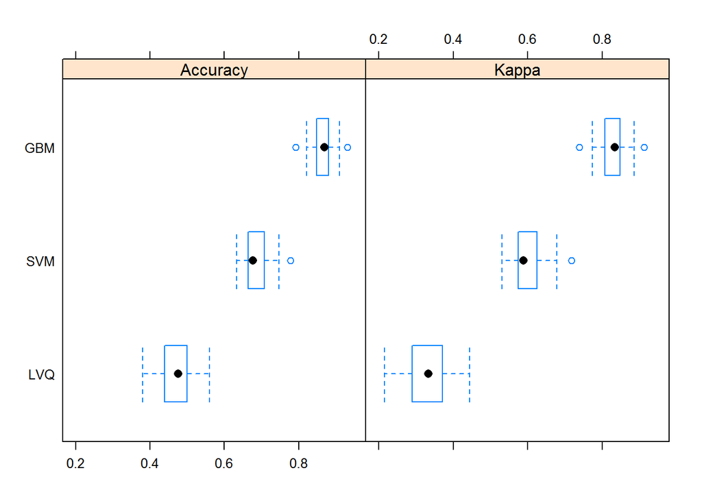

From the plot, it can be seen that **Stochastic Gradient Boosting** model performs the best. Now, let’s do a full training.

## Training and Validation

We leave the used 1000 observations and consider the remaining data. Divide 70% of data for training and 30% for validation by the chosen best model GBM.

```r
inTrain <- createDataPartition(y=remaining.data$classe, p=0.7, list=FALSE)
training.final <- remaining.data[inTrain,]
validation.final <- remaining.data[-inTrain,]

#run model in parallel
cl <- makeCluster(detectCores())
registerDoParallel(cl)

#control list
myControl1 <- trainControl(method='cv', number = 3)

best.model <- train(classe~., data = training.final, method='gbm', trControl=myControl1,verbose = FALSE)

stopCluster(cl)

# Confusion Matrix

Prediction <- predict(best.model, validation.final[,-32])
confusionMatrix(Prediction,validation.final$classe)
```

```
## Confusion Matrix and Statistics
##
##           Reference
## Prediction    A    B    C    D    E
##          A 1558   37    0    0    3
##          B   14  995   50    7   16
##          C   13   43  916   30   19
##          D    5    7   10  868   20
##          E    1    2    2    4  965
##
## Overall Statistics
##
##                Accuracy : 0.9493
##                  95% CI : (0.9432, 0.9549)
##     No Information Rate : 0.2849
##     P-Value [Acc > NIR] : < 2.2e-16
##
##                   Kappa : 0.9359
##  Mcnemar's Test P-Value : 4.317e-12
##
## Statistics by Class:
##
##                      Class: A Class: B Class: C Class: D Class: E
## Sensitivity            0.9793   0.9179   0.9366   0.9549   0.9433
## Specificity            0.9900   0.9807   0.9772   0.9910   0.9980
## Pos Pred Value         0.9750   0.9196   0.8972   0.9538   0.9908
## Neg Pred Value         0.9917   0.9802   0.9864   0.9912   0.9874
## Prevalence             0.2849   0.1941   0.1751   0.1628   0.1832
## Detection Rate         0.2790   0.1782   0.1640   0.1554   0.1728
## Detection Prevalence   0.2861   0.1937   0.1828   0.1629   0.1744
## Balanced Accuracy      0.9846   0.9493   0.9569   0.9730   0.9707
```

GBM model achieves 94% accuracy on the validation data.

## Conclusion

```r
varImp(best.model)
```

```
## gbm variable importance
##
##   only 20 most important variables shown (out of 31)
##
##                      Overall
## magnet_belt_y        100.000
## pitch_forearm         91.789
## yaw_belt              88.252
## magnet_dumbbell_z     64.772
## roll_forearm          46.474
## gyros_belt_z          45.745
## roll_dumbbell         45.194
## gyros_dumbbell_y      29.117
## accel_forearm_z       28.559
## accel_forearm_x       23.290
## total_accel_dumbbell  19.641
## magnet_forearm_z      16.966
## yaw_arm               13.280
## pitch_dumbbell        12.412
## magnet_arm_z          11.365
## gyros_belt_y           9.891
## roll_arm               8.793
## gyros_belt_x           7.945
## magnet_forearm_x       7.890
## yaw_dumbbell           7.493
```

[output not shown]